# CART

Marcela

Consideramos el conjunto de datos $\mathtt{titanic}$, de la libreria titanic, el mismos cuenta con diferentes variables que caracterizan a los pasageros del barco y una etiqueta $\mathtt{suvival}$ que indica si sobrevive o no.

Separamos a el 75% de los datos para entrenar el modelo y los restantes para validarlo.

```r
set.seed(123)
training_sample = sample(c(TRUE, FALSE), nrow(titanic_train), replace = T, prob = c(0.75,0.25))
train = titanic_train[training_sample, ]
test = titanic_train[!training_sample, ]
```

Primero es adecuado hacer un an'alisis exploratorio de los datos.

```r
#Analisis en funcion del sexo.
summary(train$Sex)
```

```
##    Length     Class      Mode
##       674 character character
```

```r
prop.table(table(train$Sex, train$Survived))
```

```
##
##                   0          1
##   female 0.09347181 0.25667656
##   male   0.52670623 0.12314540
```

```r
#la mayor parte de la mujeres viven y de los hombres mueren

prop.table(table(train$Sex, train$Survived), 1)
```

```
##
##                  0         1
##   female 0.2669492 0.7330508
##   male   0.8105023 0.1894977
```

```r
#miramos las distribucione marginales por sexo

#Analisis en funcion de la edad.
#Estas tablas muestran que pasa con los mayores y menores de 18 anios.

summary(train$Age)
```

```
##    Min. 1st Qu.  Median    Mean 3rd Qu.    Max.    NA's
##    0.42   21.00   28.00   29.75   38.00   74.00     141
```

```r
train$Child <- 0
train$Child[train$Age < 18] <- 1
aggregate(Survived ~ Child + Sex, data=train, FUN=sum)
```

```
##   Child    Sex Survived
## 1     0 female      147
## 2     1 female       26
## 3     0   male       64
## 4     1   male       19
```

```r
aggregate(Survived ~ Child + Sex, data=train, FUN=length)
```

```
##   Child    Sex Survived
## 1     0 female      198
## 2     1 female       38
## 3     0   male      393
## 4     1   male       45
```

```r
aggregate(Survived ~ Child + Sex, data=train, FUN=function(x) {sum(x)/length(x)})
```

```
##   Child    Sex  Survived
## 1     0 female 0.7424242
## 2     1 female 0.6842105
## 3     0   male 0.1628499
## 4     1   male 0.4222222
```

```r
# Analisis conjunto de clases y tarifas, estas variables necesariamente estan altamente correlacionadas
train$Fare2 <- '30+'
train$Fare2[train$Fare < 30 & train$Fare >= 20] <- '20-30'
train$Fare2[train$Fare < 20 & train$Fare >= 10] <- '10-20'
train$Fare2[train$Fare < 10] <- '<10'
aggregate(Survived ~ Fare2 + Pclass + Sex, data=train, FUN=function(x) {sum(x)/length(x)})
```

```
##    Fare2 Pclass    Sex  Survived
## 1  20-30      1 female 0.7500000
## 2    30+      1 female 0.9696970
## 3  10-20      2 female 0.8888889
## 4  20-30      2 female 0.8636364
## 5    30+      2 female 1.0000000
## 6    <10      3 female 0.5686275
## 7  10-20      3 female 0.5937500
## 8  20-30      3 female 0.3750000
## 9    30+      3 female 0.1818182
## 10   <10      1   male 0.0000000
## 11 20-30      1   male 0.4090909
## 12   30+      1   male 0.3432836
## 13   <10      2   male 0.0000000
## 14 10-20      2   male 0.1666667
## 15 20-30      2   male 0.2000000
## 16   30+      2   male 0.2727273
## 17   <10      3   male 0.1111111
## 18 10-20      3   male 0.2307692
## 19 20-30      3   male 0.1764706
## 20   30+      3   male 0.2500000
```

Comenzamos con la clasificacion. Primero hacemos un arbol corto, utilizando unicamente como variables regresoras $\mathtt{Pclas}$, $\mathtt{Sex}$ y $\mathtt{Embarked}$, las tres son categoricas, la ultima indica el puerto donde se embarco cada pasagero.

[figure not shown]

```r
titanic.tree.1<- rpart(Survived ~ Pclass + Sex+ Embarked  , data=train, method="class")
fancyRpartPlot(titanic.tree.1)
```

Analizamos este arbol. La primera rama tiene todos los datos y nos indica que el 62% de los pasageros muere. Ese nodo se clasifica con un cero, que indica que mueren y tiene una tasa de datos mal clasificado del 38%. Se bifurca de acuerdo a la variable $\mathtt{Sex}.$ La rama izquierda indica los hombres (65% de la poblacion), en ese caso el nodo nuevamente es clasificados como cero, en este caso, el 81% de los hombres mueren. La rama derecha tiene a las mujeres, esta nodo se clasifica como un 1, que indica que viven y la tasa de datos mal clasificados es el 27% y tiene al 35% de la poblacion.

Este procedimiento se repite ahora en cada uno de los nodos $\mathit{hijos}.$ El de los hombres es un nodo terminal, es decir que no se vuelve a bifurcar, mientras que el de las mujeres se bifurca dependiendo de la variable $\mathtt{Pclass},$ los analisis en los diferentes nodos son analogos.

[figure not shown]

```r
tit.tree.max <- rpart(Survived ~ Pclass + Sex + Age + SibSp + Parch + Fare + Embarked, data=train,
             method="class", control=rpart.control(minsplit=2, cp=0))
fancyRpartPlot(tit.tree.max)
```

Como vemos nos queda un arbol muy complejo, que no se puede interpretar facilmente y una de las principales ventajas de CART es su facil interpretacion. Por otra parte, este arbol sufre de sobreajuste.

Buscando solucionar estos problemas, sobre todo el sobreajuste, podamos el arbol. El parametro $\alpha$ del criterio de pruning, se selecciona mediante cross validation. El valor inicial para $\mathtt{cp}$ hay que setearlo bajo.

[figure not shown]

```r
#Paso 1: Comenzamos con un cp bajo

tit.tree.grow <- rpart(Survived ~ Pclass + Sex + Age + SibSp + Parch + Fare + Embarked, data=train,
                       method="class",control = rpart.control(cp = 0.0001))
fancyRpartPlot(tit.tree.grow)
```

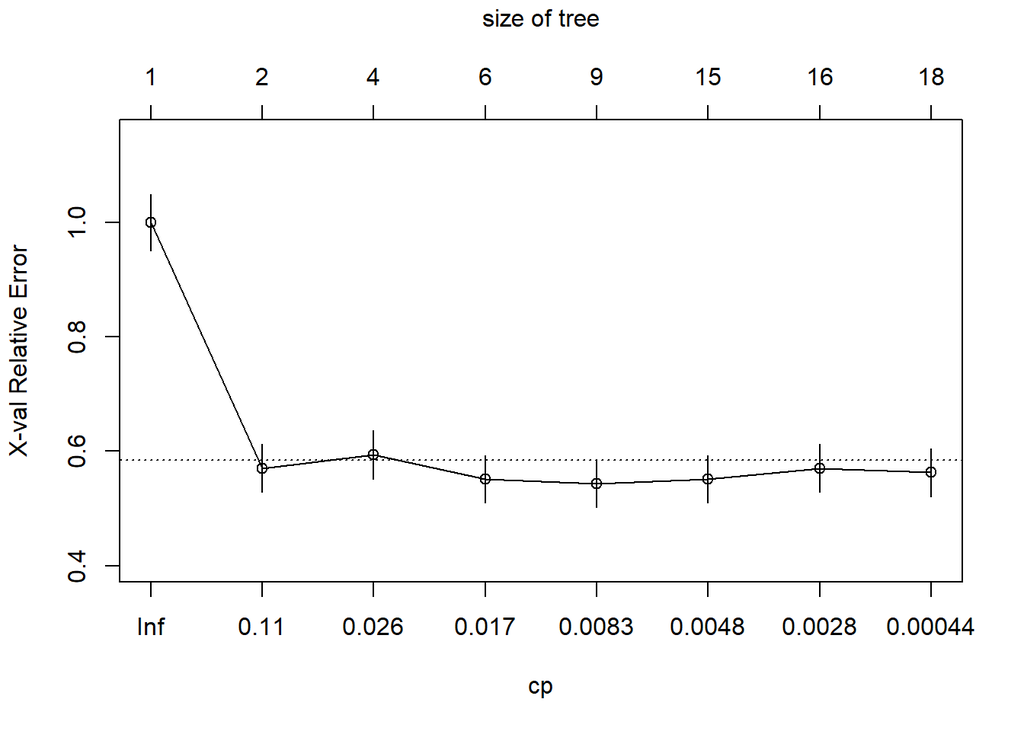

```r
#Ac攼㸱 podemos ver como fueron los parametros de la cross validacion
plotcp(tit.tree.grow)
```

```r
printcp(tit.tree.grow)
```

```
##
## Classification tree:
## rpart(formula = Survived ~ Pclass + Sex + Age + SibSp + Parch +
##     Fare + Embarked, data = train, method = "class", control = rpart.control(cp = 1e-04))
##
## Variables actually used in tree construction:
## [1] Age    Fare   Pclass Sex    SibSp
##
## Root node error: 256/674 = 0.37982
##
## n= 674
##
##          CP nsplit rel error  xerror     xstd
## 1 0.4296875      0   1.00000 1.00000 0.049220
## 2 0.0273438      1   0.57031 0.57031 0.041776
## 3 0.0253906      3   0.51562 0.59375 0.042383
## 4 0.0117188      5   0.46484 0.55078 0.041248
## 5 0.0058594      8   0.42969 0.54297 0.041031
## 6 0.0039062     14   0.38672 0.55078 0.041248
## 7 0.0019531     15   0.38281 0.57031 0.041776
## 8 0.0001000     17   0.37891 0.56250 0.041567
```

[figure not shown]

```r
#  Paso 2: Elegir el tamanio del arbol que minimice la tasa de datos mal clasificados (i.e. error de prediccion).
# Buscamos el valor de cp que minimice xerror con el arbol mas simple.

bestcp <- tit.tree.grow$cptable[which.min(tit.tree.grow$cptable[,"xerror"]),"CP"]

# Paso 3: Podar el arbol maximal usando el mejor cp.
tit.pruned <- prune(tit.tree.grow, cp = bestcp)

fancyRpartPlot(tit.pruned)
```

Pasemos ahora a clasificar las observaciones de la muestra de testeo.

```r
pred.prune = predict(tit.pruned, test, type = "class")

#Matriz de confusion  (test data)
conf.matrix <- table(test$Survived, pred.prune)
rownames(conf.matrix) <- paste("Actual", rownames(conf.matrix), sep = ":")
colnames(conf.matrix) <- paste("Pred", colnames(conf.matrix), sep = ":")
print(conf.matrix)
```

```
##           pred.prune
##            Pred:0 Pred:1
##   Actual:0    125      6
##   Actual:1     27     59
```

Cambio ahora los criterios de impureza, repetimos el analisis, como es de esperar cambian los arboles y las tasa de datos mal clasificados en consecuencia.

Comenzamos considerando el criterio de $\mathtt{informacion}$

[figure not shown]

```r
tit.tree.infor=rpart(Survived ~ Pclass + Sex + Age + SibSp + Parch + Fare + Embarked, data=train,
                       method="class",control = rpart.control(cp = 0.0001),parms = list(split= 'information'))
bestcp <- tit.tree.infor$cptable[which.min(tit.tree.infor$cptable[,"xerror"]),"CP"]

tit.pruned.infor <- prune(tit.tree.infor, cp = bestcp)
fancyRpartPlot(tit.pruned.infor)
```

Luego el criterio de $\mathtt{gini}.$

[figure not shown]

```r
tit.tree.gini <- rpart(Survived ~ Pclass + Sex + Age + SibSp + Parch + Fare + Embarked, data=train,
                        method="class",control = rpart.control(cp = 0.0001),parms = list(split= 'gini'))
bestcp <- tit.tree.gini$cptable[which.min(tit.tree.gini$cptable[,"xerror"]),"CP"]

tit.pruned.gini <- prune(tit.tree.gini, cp = bestcp)


fancyRpartPlot(tit.pruned.gini)
```

Pasamos ahora a los clasificadores $\mathbf{agregados}.$

Comenzamos con los $\mathbf{Bagging.}$ En este caso consideramos muestras bootstrap de la muestra de entrenamiento, en base a las mismas construimos arboles de clasificacion, que no podamos. Estos arboles tienen bajo sesgo y alta varianza. Asignamos las observaciones a la clase mas votada, de este modo buscamos disminuir la varianza.

Tenemos que llamar a la libreria $\mathtt{RandomForest}.$

```r
library (randomForest)
train=na.omit(train)
#Importante que la variable de respuesta sea categorica sino hace bagging pero con regresion.
train$Survived=as.factor(train$Survived)

bag.tit =randomForest(Survived ~ Pclass + Sex + Age + SibSp + Parch + Fare + Embarked, data=train,ntree=500,mtry=7, importance =TRUE)
#mtry=7 nro de variables, al poner todas bagging es un caso particular de RF

#Analizamos la salida. Nos indica la tasa de error de las observaciones out of the bag y tambien da la matriz de confusion para los mismos datos.
bag.tit
```

```
##
## Call:
##  randomForest(formula = Survived ~ Pclass + Sex + Age + SibSp +      Parch + Fare + Embarked, data = train, ntree = 500, mtry = 7,      importance = TRUE)
##                Type of random forest: classification
##                      Number of trees: 500
## No. of variables tried at each split: 7
##
##         OOB estimate of  error rate: 23.45%
## Confusion matrix:
##     0   1 class.error
## 0 262  56   0.1761006
## 1  69 146   0.3209302
```

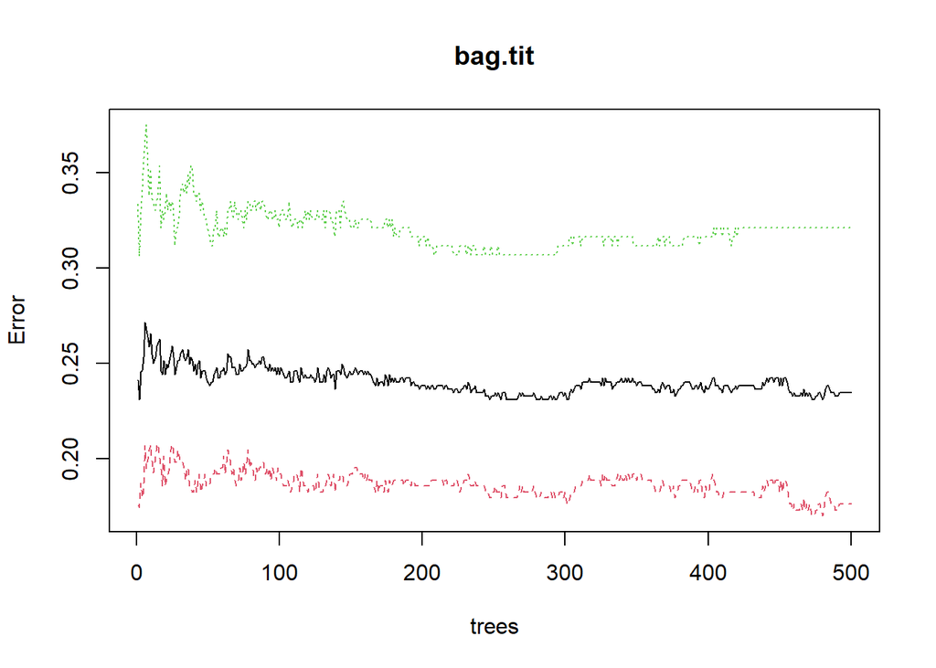

```r
# Grafica las tasas de error globales y para cada categoria a medida que toma mas muestras bootstrap
plot(bag.tit)
```

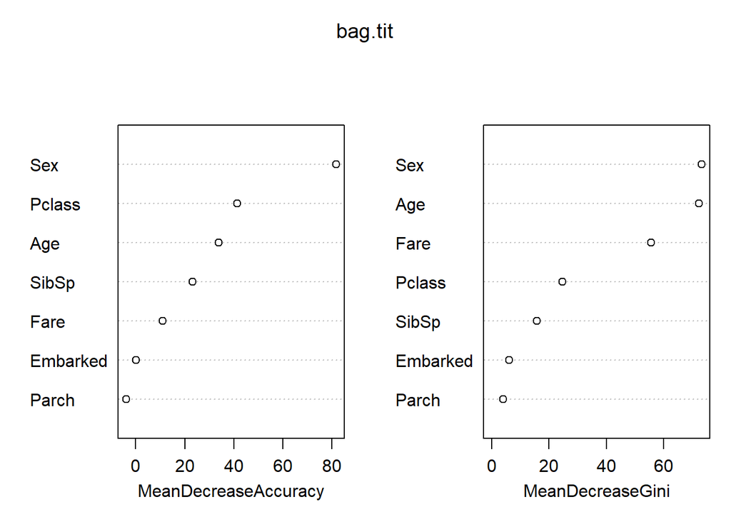

```r
# Muestra la importancia de cada variable, dependiendo del criteio de impureza considerado.
varImpPlot(bag.tit,sort = TRUE)
```

```r
#Prediccion en un nuevo conjunto de datos

pred.tit.bag = predict (bag.tit ,newdata =test)

#confusion matrix (test data)
conf.matrix <- table(test$Survived, pred.tit.bag)
rownames(conf.matrix) <- paste("Actual", rownames(conf.matrix), sep = ":")
colnames(conf.matrix) <- paste("Pred", colnames(conf.matrix), sep = ":")
print(conf.matrix)
```

```
##           pred.tit.bag
##            Pred:0 Pred:1
##   Actual:0     95     11
##   Actual:1     16     59
```

Ahora hacemos random forest, en este caso en cada nodo se seleccionan un conjunto de orden $\sqrt{p}=m$ de parametros para construir el arbol y de este modo superar el problema de la tree $\mathit{tree}$ $\mathit{correlation.}$ El analisis es analogo al anterior.

```r
#Random Forest
rf.tit =randomForest(Survived ~ Pclass + Sex + Age + SibSp + Parch + Fare + Embarked, data=train,ntree=500,mtry=2, importance =TRUE)
#mtry=2 indica cuantas variables sorteo en cada corte.
rf.tit
```

```
##
## Call:
##  randomForest(formula = Survived ~ Pclass + Sex + Age + SibSp +      Parch + Fare + Embarked, data = train, ntree = 500, mtry = 2,      importance = TRUE)
##                Type of random forest: classification
##                      Number of trees: 500
## No. of variables tried at each split: 2
##
##         OOB estimate of  error rate: 19.7%
## Confusion matrix:
##     0   1 class.error
## 0 283  35   0.1100629
## 1  70 145   0.3255814
```

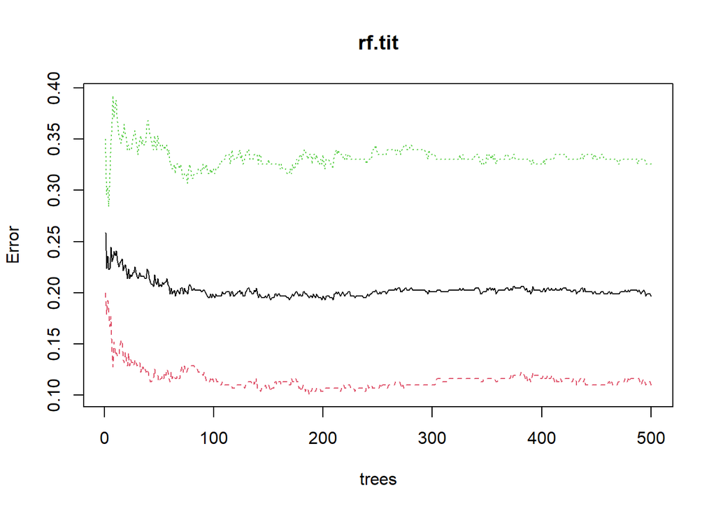

```r
#Grafico con los errores
plot(rf.tit)
```

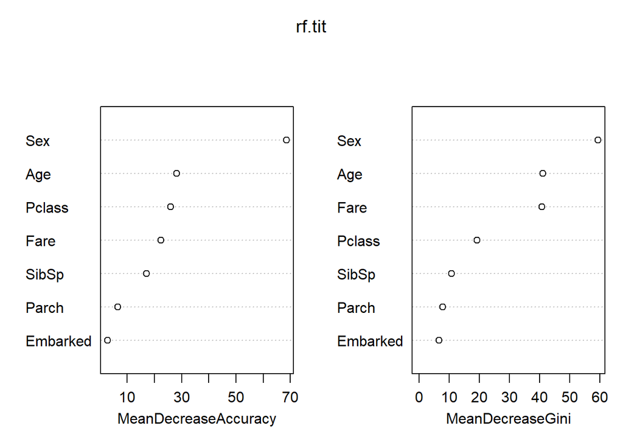

```r
#Grafico con la importancia de las variables regresoras.
varImpPlot(rf.tit,sort = TRUE)
```

```r
#Prediccion en un nuevo conjunto de datos
pred.tit.rf = predict (rf.tit ,newdata =test)

#confusion matrix (test data)
conf.matrix <- table(test$Survived, pred.tit.rf)
rownames(conf.matrix) <- paste("Actual", rownames(conf.matrix), sep = ":")
colnames(conf.matrix) <- paste("Pred", colnames(conf.matrix), sep = ":")
print(conf.matrix)
```

```
##           pred.tit.rf
##            Pred:0 Pred:1
##   Actual:0    100      6
##   Actual:1     20     55
```

Por ultimo aplicamos $\mathbf{boosting},$ en este caso se construye una sucesion de clasificadores que en cada paso da mas peso a las observaciones mal clasificadas en el paso anterior. De esta forma busca centrarse en resolver los problemas dificiles mejorando el desempenio global.

En este caso llamo a la libreria $\mathtt{C50},$ que tambien se puede usar para hacer CART

```r
library("C50")
train$Survived=as.factor(train$Survived)
boost.tit <- C5.0(Survived ~ Pclass + Sex + Age + SibSp + Parch + Fare , data = train, trials = 50)

boost.tit
```

```
##
## Call:
## C5.0.formula(formula = Survived ~ Pclass + Sex + Age + SibSp + Parch +
##  Fare, data = train, trials = 50)
##
## Classification Tree
## Number of samples: 533
## Number of predictors: 6
##
## Number of boosting iterations: 50 requested;  13 used due to early stopping
## Average tree size: 4.9
##
## Non-standard options: attempt to group attributes
```

```r
xtest=test[,-c(1,2)]
pred= predict(boost.tit, newdata = xtest, type = "class")
table(predicho = pred, real = test$Survived)
```

```
##         real
## predicho   0   1
##        0 118  24
##        1  13  62
```

```r
library(tree)
library(MASS)
data("Boston")


train = sample (1: nrow(Boston ), nrow(Boston )/2)
tree.boston =tree(medv~.,Boston ,subset =train)
summary(tree.boston)
```

```
##
## Regression tree:
## tree(formula = medv ~ ., data = Boston, subset = train)
## Variables actually used in tree construction:
## [1] "lstat" "rm"    "dis"   "nox"   "crim"
## Number of terminal nodes:  10
## Residual mean deviance:  11.94 = 2902 / 243
## Distribution of residuals:
##    Min. 1st Qu.  Median    Mean 3rd Qu.    Max.
## -14.600  -1.920  -0.120   0.000   1.872  16.480
```

[figure not shown]

```r
plot(tree.boston)
```

[figure not shown]

```r
#text(tree.boston,pretty =0)


#Ahora lo podamos, cross validando el parametro de penalidad alfa.

cv.boston=cv.tree(tree.boston)


prune.boston=prune.tree(tree.boston ,best =5)

plot(prune.boston )
```

```r
#text(prune.boston ,pretty =0)
```